# Your Compact Report

# Data and Preprocessing

## Data description

The dataset used for this project is the Breast Cancer Wisconsin (Diagnostic) Dataset (WDBC), a classic benchmark for classification sourced from the UCI Machine Learning Repository.

The dataset contains 569 observations of breast mass samples. The problem is a binary classification task, where the target variable, diagnosis, is classified as either Malignant (212 observations) or Benign (357 observations).

Each instance is described by 30 numeric features that were computed from a digitized image of a fine needle aspirate (FNA) of the breast mass. Each image yields **10 basic features** that describe characteristics of the cell nucleus:

| Feature | Description |
| --- | --- |
| **Radius** | Average distance from center to perimeter points (nucleus size) |
| **Texture** | Variation in gray-scale intensity (smoothness vs. roughness) |
| **Perimeter** | Length around the boundary of the nucleus |
| **Area** | Total size of the nucleus |
| **Smoothness** | Local variation in radius lengths (edge regularity) |
| **Compactness** | Measure of shape compactness, $(\text{perimeter}^2 / \text{area}) - 1.0$ |
| **Concavity** | Severity of inward curvature along the boundary |
| **Concave Points** | Number of distinct inward curvature points |
| **Symmetry** | Symmetry of the nucleus shape |
| **Fractal Dimension** | Complexity of the boundary (“coastline approximation”) |

For each of these 10 base features, three statistics were computed: - **Mean value** - **Standard error (SE)** - **“Worst” (largest mean of the three highest values)**

This yields **30 derived features** in total.

| Property | Variable | Value |
| --- | --- | --- |
| **Number of observations** | *n* | **569** |
| **Number of features** | *d* | **30** (plus ID and diagnosis = 32 total columns) |
| **Feature types** | — | **Continuous: 30**, **Categorical: 1 (diagnosis)** |
| **Number of classes (for classification)** | *C* | **2** *(Malignant, Benign)* |
| **Class distribution** | — | **212 Malignant (37%)**, **357 Benign (63%)** — *imbalanced* |
| **Missing values percentage** | — | **0% (no missing data)** |

- The dataset provides **numeric**, **well-structured**, and **clean** measurements ideal for supervised learning.
- The classification task is **binary** and slightly **imbalanced** toward the benign class.
- All features are **continuous**, making it suitable for algorithms like **Logistic Regression**, **Gaussian Naive Bayes**, or **Perceptron Algorithm**.

## Preprocessing steps

### Missing values

```
## Total missing values in the entire dataset: 0
```

### Outliers, features distributions - scales

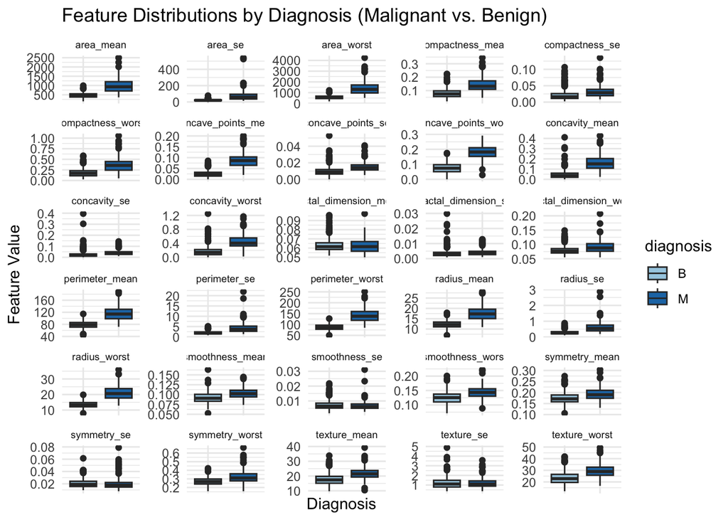

```r
# To plot all 30 features at once, we first "pivot" the data
# into a "long" format. This is the standard tidyverse way.
data_long <- data_clean %>%
  pivot_longer(
    cols = -diagnosis,       # Pivot every column *except* 'diagnosis'
    names_to = "feature",    # New column for the feature name
    values_to = "value"      # New column for its value
  )

ggplot(data_long, aes(x = diagnosis, y = value, fill = diagnosis)) +
  geom_boxplot() +
  facet_wrap(~feature, scales = "free_y", ncol = 5) +
  scale_fill_brewer(palette = "Paired") +
  labs(
    title = "Feature Distributions by Diagnosis (Malignant vs. Benign)",
    x = "Diagnosis",
    y = "Feature Value"
  ) +
  theme_minimal() +
  theme(
    axis.text.x = element_blank(),  # Hide x-axis labels for a cleaner look
    axis.ticks.x = element_blank(),
    strip.text = element_text(size = 7) # Smaller facet labels
  )
```

- **Outliers (Anomalous Value):** We immediately observed the presence of numerous outliers, represented by individual observations outside the IQR range. These are particularly present in features like `area_mean`, `area_worst`, and `concavity_worst`. However, because those trust the original source, we know that these are not data entry errors but likely represent true, extreme biological values. Therefore, we made the decision not to remove these outliers, as they are part of the real-world problem. We will proceed with the full dataset, relying on our models to be robust enough to handle this variance.

### Normalization

Our plot also highlights the vast difference in scales across features. Gradient-based models like the Perceptron and Logistic Regression (GLM) are sensitive to feature scales. Without normalization, features with larger magnitudes would dominate the learning process. This plot provides a clear justification for standardizing the features before modeling.

### Elimination of irrelevant variables

For nearly every feature, the boxplot for the Malignant (M) class is visually distinct from the boxplot for the Benign (B) class. The medians, quartiles, and overall ranges show clear separation. This is an excellent sign, as it indicates that our features contain strong predictive information, and we can expect our models to perform well.

```r
# With AI
nzv_check <- nearZeroVar(data_clean, saveMetrics = TRUE)

# Filter to see only the features that *might* be a problem
# A "TRUE" in the 'nzv' column means it's a candidate for removal.
problematic_features <- nzv_check[nzv_check$nzv == TRUE, ]

# Print the results
if (nrow(problematic_features) > 0) {
  cat("Found", nrow(problematic_features), "near-zero variance features:\n")
  print(problematic_features)
} else {
  cat("No near-zero variance features found. All features have sufficient variance.\n")
}
```

```
## No near-zero variance features found. All features have sufficient variance.
```

First, we checked for “irrelevant” features by running a “Near-Zero Variance” (NZV) test. This test finds any feature that is constant or nearly constant, as a feature that doesn’t change cannot be a predictor. We used the `caret::nearZeroVar()` function to check all 30 features.

we note that we used AI to help confirm this was the correct tool for this task.

The NZV test showed that all 30 features have enough variance, so we did not eliminate any features at this step.

### Elimination of redundant variables

Our primary tool for this step was correlation analysis. We first calculated the correlation matrix for all numeric features and visualized it using a heatmap.

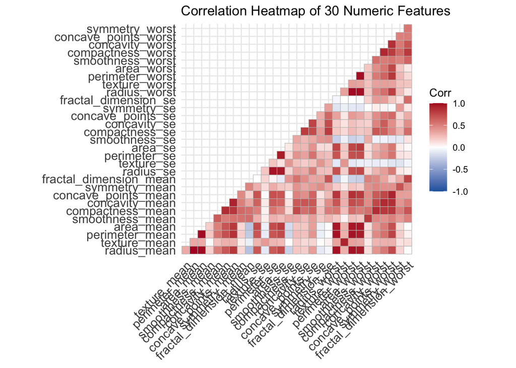

```r
# Correlation matrix.
# numeric features selections
numeric_features <- data_clean %>%
  select_if(is.numeric)

cor_matrix <- cor(numeric_features)

# Plot the correlation heatmap
ggcorrplot(cor_matrix,
  type = "lower",
  lab = FALSE,
  colors = c("#2166AC", "white", "#B2182B"),
  title = "Correlation Heatmap of 30 Numeric Features"
)
```

The heatmap immediately revealed large blocks of high correlation (dark red), confirming that our dataset contains significant multicollinearity. For example, features related to tumor size, like radius_mean, perimeter_mean, and area_mean, are all nearly perfectly correlated.

```r
# Correlation and cutoff

highly_correlated_features <- findCorrelation(cor_matrix, cutoff = 0.90, names = TRUE)


cat("Found", length(highly_correlated_features), "redundant features to remove (cutoff > 0.90):\n")
```

```
## Found 10 redundant features to remove (cutoff > 0.90):
```

```r
print(highly_correlated_features)
```

```
##  [1] "concavity_mean"      "concave_points_mean" "perimeter_worst"
##  [4] "radius_worst"        "perimeter_mean"      "area_worst"
##  [7] "radius_mean"         "perimeter_se"        "area_se"
## [10] "texture_mean"
```

```r
# Create the reduced Dataset

data_clean_reduced <- data_clean %>%
  select(-all_of(highly_correlated_features))

cat("\nOriginal data had", ncol(data_clean), "columns (30 features + 1 target).\n")
```

```
##
## Original data had 31 columns (30 features + 1 target).
```

```r
cat("Reduced data has", ncol(data_clean_reduced), "columns.\n")
```

```
## Reduced data has 21 columns.
```

While the heatmap is excellent for visualization, we use a correlation matrix and a cutoff of 0.90 (standard threshold) for reducing feature redundancy. This function automatically identifies the minimum number of features to remove to ensure that no two features in the remaining dataset have a correlation greater than 0.90.

This analysis identified 10 features as redundant.

### Normalization of the variables

done in models

# Methodology

## Experimental protocol

After cleaning and reducing the original dataset to 20 key features, the data is split into **80% training** and **20% holdout** sets to ensure fair evaluation. All models are trained using **10-fold cross-validation** to obtain robust performance estimates and minimize overfitting.

Three groups of experiments are conducted to assess the impact of different feature representations on classification accuracy:

1. **Experiment 1 – Baseline (Reduced Features):** Models (GLM, Gaussian Naive Bayes, and Linear SVM) are trained using the 20 selected features after centering and scaling.
2. **Experiment 2 – PCA Components:** The same models are trained on **Principal Component Analysis (PCA)**–transformed data, where dimensionality reduction captures the main variance directions in the dataset.
3. **Experiment 3 – LDA Component:** A **Linear Discriminant Analysis (LDA)** model is first trained to extract a single discriminant component (LD1) summarizing the separation between classes. GLM, Naive Bayes, and SVM are then retrained using only this new feature to test the effectiveness of supervised dimensionality reduction.

```
## Starting Experiment 1: 20 Reduced Features
```

```
## Starting Experiment 2: PCA Components
```

```
## Starting Experiment 3: LDA Component (2-Step Method)
```

```
## Training LDA model (to be used as transformer)...
```

```
## Extracting LD1 component...
```

```
## Training GLM on LDA component...
```

```
## Training GNB on LDA component...
```

```
## Training SVM on LDA component...
```

```
## All LDA-component models trained.
```

## Method 1: Generalized Linear Model (GLM)

### Model formulation

A **Generalized Linear Model (GLM)** assumes that the response variable $Y$ follows a distribution from the exponential family and that its mean $\mu = \mathbb{E}[Y|X]$ is related to a linear predictor through a *link function* $g(\cdot)$:
$$g(\mu) = \beta_0 + \beta_1 x_1 + \cdots + \beta_d x_d.$$
For binary classification, the model used is **logistic regression**, with
$$g(\mu) = \text{logit}(\mu) = \log\left(\frac{\mu}{1 - \mu}\right),$$
which ensures predictions stay between 0 and 1.

### Theoretical properties and justification

GLMs are statistically grounded, interpretable, and perform well when the relationship between predictors and the log-odds of the outcome is approximately linear. They provide *probabilistic outputs* and naturally model class probabilities. Logistic regression also maximizes the likelihood of observed labels under a Bernoulli distribution, making it robust for well-separated classes.

### Implementation details

The GLM was implemented using the `train()` function from the **caret** package with `method = "glm"`, applying **centering and scaling** as preprocessing. Model fitting uses **Iteratively Reweighted Least Squares (IRLS)** to find the maximum-likelihood estimates of $\beta$. Regularization was not applied in this baseline version.

## Method 2: Gaussian Naive Bayes (GNB)

### Model formulation

Gaussian Naive Bayes models the class-conditional distribution of each feature as Gaussian:
$$p(x_j | y = c) = \frac{1}{\sqrt{2\pi\sigma_{jc}^2}}
\exp\!\left(-\frac{(x_j - \mu_{jc})^2}{2\sigma_{jc}^2}\right),$$
and applies Bayes’ rule assuming **conditional independence** between features:
$$p(y|x) \propto p(y)\prod_{j=1}^d p(x_j|y).$$
The predicted class is the one with the highest posterior probability.

### Theoretical properties and justification

Despite the strong independence assumption, Naive Bayes often performs surprisingly well in practice, especially when features are only weakly correlated. It is simple, fast, and provides a strong probabilistic baseline. GNB is particularly effective when the class distributions are approximately normal and separable in feature space.

### Implementation details

Implemented via `method = "nb"` in **caret**, with preprocessing including **centering and scaling**. The algorithm estimates each feature’s mean and variance per class, then computes log-posterior probabilities for classification. No parameter tuning is typically needed, making it computationally efficient.

## Method 3: Support Vector Machine (SVM)

### Model formulation

A linear Support Vector Machine seeks the hyperplane $w^\top x + b = 0$ that maximizes the margin between two classes:
$$\min_{w,b} \frac{1}{2}\|w\|^2 + C \sum_{i=1}^n \max(0, 1 - y_i(w^\top
x_i + b)),$$
where $C > 0$ balances margin width and classification error (hinge loss). The prediction function is
$$f(x) = \text{sign}(w^\top x + b).$$

### Theoretical properties and justification

SVMs are **margin-based classifiers** that provide good generalization, especially in high-dimensional spaces. The hinge loss focuses on difficult cases (support vectors), making the classifier robust to noise and overfitting. A linear kernel is used here since the dataset is well-behaved and moderately dimensional.

### Implementation details

Implemented using `method = "svmLinear"` in **caret**, with **10-fold cross-validation**. Features were **centered and scaled** before training. The regularization parameter $C$ was tuned automatically using internal resampling to optimize performance.

## Comparison framework

To ensure a fair comparison, all models were trained using: - The **same 10-fold cross-validation** (`trainControl(method="cv", number=10)`), - The **same training/holdout splits**, and - The **same preprocessing pipeline** (centering and scaling).

# Discussion of results

## Final results

```r
# --- 8. Final Results Comparison (Corrected) ---
# We now collect all our models.
all_model_results <- resamples(list(
  # Experiment 1 (Reduced 20 Features)
  GLM_Reduced = model_glm_reduced,
  GNB_Reduced = model_gnb_reduced,
  SVM_Reduced = model_svm_reduced,
  LDA_Reduced = model_lda_reduced,

  # Experiment 2 (PCA Components)
  GLM_PCA     = model_glm_pca,
  GNB_PCA     = model_gnb_pca,
  SVM_PCA     = model_svm_pca,

  # Experiment 3 (LDA Component)
  GLM_LDA_Comp = model_glm_lda,
  GNB_LDA_Comp = model_gnb_lda,
  SVM_LDA_Comp = model_svm_lda
))

# 1. Show the summary table
cat("Final CV Performance Summary:\n")
```

```
## Final CV Performance Summary:
```

```r
summary(all_model_results)
```

```
##
## Call:
## summary.resamples(object = all_model_results)
##
## Models: GLM_Reduced, GNB_Reduced, SVM_Reduced, LDA_Reduced, GLM_PCA, GNB_PCA, SVM_PCA, GLM_LDA_Comp, GNB_LDA_Comp, SVM_LDA_Comp
## Number of resamples: 10
##
## Accuracy
##                   Min.   1st Qu.    Median      Mean   3rd Qu.      Max. NA's
## GLM_Reduced  0.8888889 0.9170290 0.9565217 0.9451208 0.9777778 0.9782609    0
## GNB_Reduced  0.8666667 0.8894928 0.9120773 0.9122222 0.9347826 0.9565217    0
## SVM_Reduced  0.8913043 0.9399758 0.9560386 0.9604831 0.9944444 1.0000000    0
## LDA_Reduced  0.8666667 0.9402174 0.9565217 0.9537681 0.9777778 1.0000000    0
## GLM_PCA      0.9111111 0.9336957 0.9780193 0.9625121 0.9782609 1.0000000    0
## GNB_PCA      0.8444444 0.8888889 0.9347826 0.9208213 0.9562802 0.9782609    0
## SVM_PCA      0.9555556 0.9565217 0.9671498 0.9736715 0.9945652 1.0000000    0
## GLM_LDA_Comp 0.9130435 0.9347826 0.9666667 0.9650725 1.0000000 1.0000000    0
## GNB_LDA_Comp 0.9130435 0.9555556 0.9777778 0.9660225 0.9782609 1.0000000    1
## SVM_LDA_Comp 0.9333333 0.9557971 0.9777778 0.9648792 0.9782609 0.9782609    0
##
## Kappa
##                   Min.   1st Qu.    Median      Mean   3rd Qu.      Max. NA's
## GLM_Reduced  0.7695391 0.8259754 0.9066384 0.8843928 0.9521785 0.9539078    0
## GNB_Reduced  0.7096774 0.7644073 0.8075748 0.8116355 0.8617234 0.9066937    0
## SVM_Reduced  0.7801147 0.8682082 0.9037959 0.9154383 0.9880446 1.0000000    0
## LDA_Reduced  0.6952596 0.8671441 0.9043659 0.8973903 0.9521785 1.0000000    0
## GLM_PCA      0.8109244 0.8602907 0.9524753 0.9200627 0.9536239 1.0000000    0
## GNB_PCA      0.6488294 0.7506651 0.8600198 0.8240334 0.9043659 0.9527721    0
## SVM_PCA      0.9032258 0.9043659 0.9305447 0.9430181 0.9884770 1.0000000    0
## GLM_LDA_Comp 0.8087318 0.8547368 0.9277022 0.9228347 1.0000000 1.0000000    0
## GNB_LDA_Comp 0.8038380 0.9032258 0.9521785 0.9248766 0.9527721 1.0000000    1
## SVM_LDA_Comp 0.8531012 0.9040928 0.9521785 0.9233203 0.9527721 0.9527721    0
```

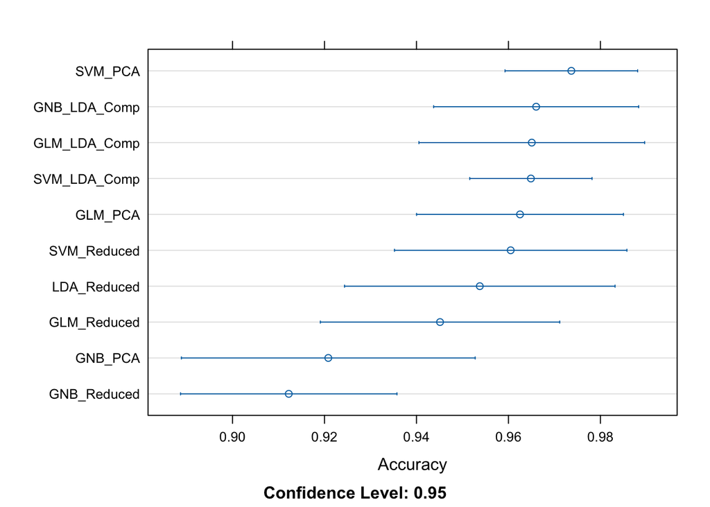

```r
# 2. Plot the results
dotplot(all_model_results, metric = "Accuracy")
```

```r
# 3. Statistical Comparison (as requested by teacher)
cat("\nFinal Statistical Comparison (Paired t-test):\n")
```

```
##
## Final Statistical Comparison (Paired t-test):
```

```r
all_model_diffs <- diff(all_model_results)
summary(all_model_diffs)
```

```
##
## Call:
## summary.diff.resamples(object = all_model_diffs)
##
## p-value adjustment: bonferroni
## Upper diagonal: estimates of the difference
## Lower diagonal: p-value for H0: difference = 0
##
## Accuracy
##              GLM_Reduced GNB_Reduced SVM_Reduced LDA_Reduced GLM_PCA
## GLM_Reduced               0.0328986  -0.0153623  -0.0086473  -0.0173913
## GNB_Reduced  1.00000                 -0.0482609  -0.0415459  -0.0502899
## SVM_Reduced  1.00000     0.13386                  0.0067150  -0.0020290
## LDA_Reduced  1.00000     1.00000     1.00000                 -0.0087440
## GLM_PCA      1.00000     0.34394     1.00000     1.00000
## GNB_PCA      1.00000     1.00000     1.00000     1.00000     1.00000
## SVM_PCA      0.81647     0.05915     1.00000     1.00000     1.00000
## GLM_LDA_Comp 1.00000     1.00000     1.00000     1.00000     1.00000
## GNB_LDA_Comp 1.00000     0.16423     1.00000     1.00000     1.00000
## SVM_LDA_Comp 1.00000     0.07574     1.00000     1.00000     1.00000
##              GNB_PCA    SVM_PCA    GLM_LDA_Comp GNB_LDA_Comp SVM_LDA_Comp
## GLM_Reduced   0.0242995 -0.0285507 -0.0199517   -0.0221685   -0.0197585
## GNB_Reduced  -0.0085990 -0.0614493 -0.0528502   -0.0587225   -0.0526570
## SVM_Reduced   0.0396618 -0.0131884 -0.0045894   -0.0099302   -0.0043961
## LDA_Reduced   0.0329469 -0.0199034 -0.0113043   -0.0025765   -0.0111111
## GLM_PCA       0.0416908 -0.0111594 -0.0025604   -0.0052067   -0.0023671
## GNB_PCA                 -0.0528502 -0.0442512   -0.0416532   -0.0440580
## SVM_PCA      0.35523                0.0085990    0.0095545    0.0087923
## GLM_LDA_Comp 0.98099    1.00000                  0.0024155    0.0001932
## GNB_LDA_Comp 1.00000    1.00000    1.00000                    0.0026302
## SVM_LDA_Comp 1.00000    1.00000    1.00000      1.00000
##
## Kappa
##              GLM_Reduced GNB_Reduced SVM_Reduced LDA_Reduced GLM_PCA
## GLM_Reduced               0.0727574  -0.0310455  -0.0129975  -0.0356699
## GNB_Reduced  0.86819                 -0.1038029  -0.0857548  -0.1084272
## SVM_Reduced  1.00000     0.10733                  0.0180480  -0.0046244
## LDA_Reduced  1.00000     1.00000     1.00000                 -0.0226724
## GLM_PCA      1.00000     0.32346     1.00000     1.00000
## GNB_PCA      1.00000     1.00000     1.00000     1.00000     1.00000
## SVM_PCA      0.78052     0.05911     1.00000     1.00000     1.00000
## GLM_LDA_Comp 1.00000     1.00000     1.00000     1.00000     1.00000
## GNB_LDA_Comp 1.00000     0.20627     1.00000     1.00000     1.00000
## SVM_LDA_Comp 1.00000     0.08351     1.00000     1.00000     1.00000
##              GNB_PCA    SVM_PCA    GLM_LDA_Comp GNB_LDA_Comp SVM_LDA_Comp
## GLM_Reduced   0.0603594 -0.0586252 -0.0384418   -0.0427030   -0.0389275
## GNB_Reduced  -0.0123979 -0.1313826 -0.1111992   -0.1238031   -0.1116848
## SVM_Reduced   0.0914050 -0.0275797 -0.0073963   -0.0188340   -0.0078820
## LDA_Reduced   0.0733569 -0.0456278 -0.0254444   -0.0050273   -0.0259300
## GLM_PCA       0.0960293 -0.0229554 -0.0027720   -0.0083823   -0.0032576
## GNB_PCA                 -0.1189847 -0.0988013   -0.0931916   -0.0992869
## SVM_PCA      0.39734                0.0201834    0.0224362    0.0196978
## GLM_LDA_Comp 1.00000    1.00000                  0.0055245   -0.0004856
## GNB_LDA_Comp 1.00000    1.00000    1.00000                    0.0048287
## SVM_LDA_Comp 1.00000    1.00000    1.00000      1.00000
```

```r
all_model_results$timings
```

|  | Everything | FinalModel | Prediction |
| --- | --- | --- | --- |
| GLM_Reduced | 0.159 | 0.004 | NA |
| GNB_Reduced | 0.729 | 0.003 | NA |
| SVM_Reduced | 0.505 | 0.005 | NA |
| LDA_Reduced | 0.075 | 0.002 | NA |
| GLM_PCA | 0.098 | 0.006 | NA |
| GNB_PCA | 0.320 | 0.002 | NA |
| SVM_PCA | 0.099 | 0.005 | NA |
| GLM_LDA_Comp | 0.058 | 0.001 | NA |
| GNB_LDA_Comp | 0.112 | 0.001 | NA |
| SVM_LDA_Comp | 0.066 | 0.001 | NA |